# Organic Matter Supply Model: Analyzing data from wild zooplankton at Station ALOHA in summer

## Diagnostics

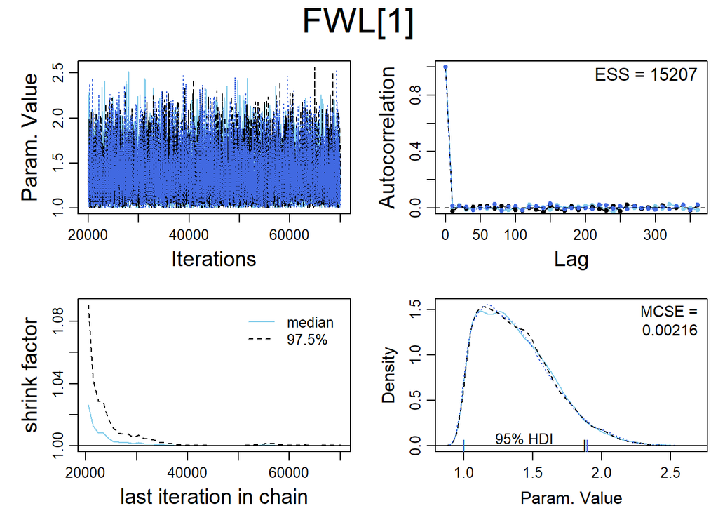

```r
## Kruschke's utility functions (edited by NF)
# edit "parname" to print additional parameter diagnostics as desired
# numbers in hard brackets pertain to samples and tracers
if (c(TRUE,FALSE)[1]) source("Utilities/DBDA2E-utilities.R")
diagMCMC(rjo_1$mcmc, parName="FWL[1]")
```

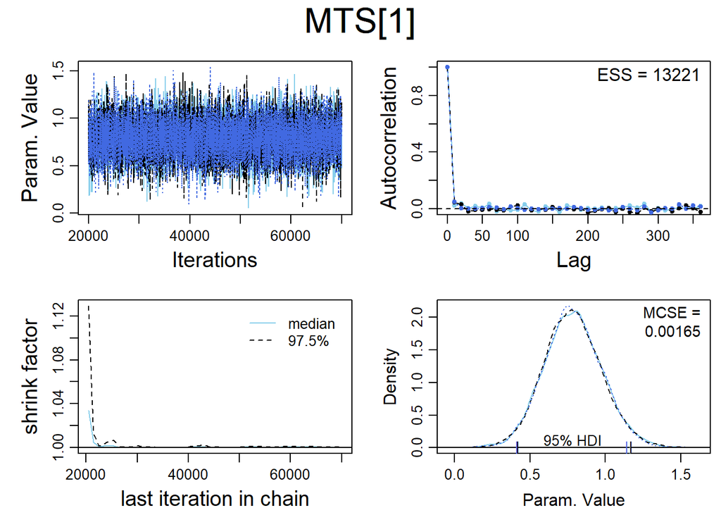

```r
diagMCMC(rjo_1$mcmc, parName="MTS[1]")
```

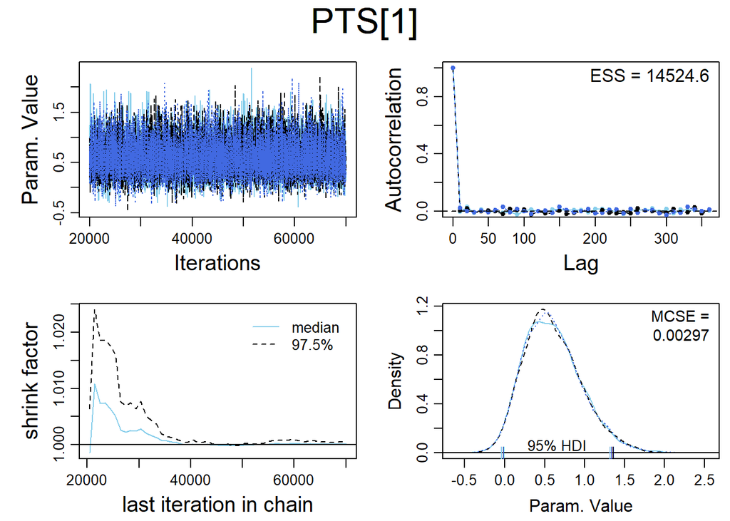

```r
diagMCMC(rjo_1$mcmc, parName="PTS[1]")
```

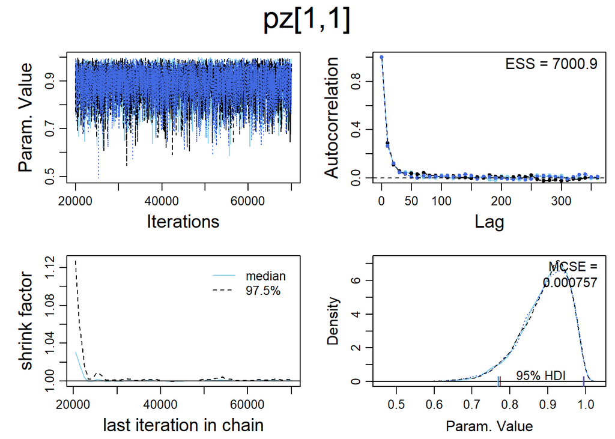

```r
diagMCMC(rjo_1$mcmc, parName="pz[1,1]")
```

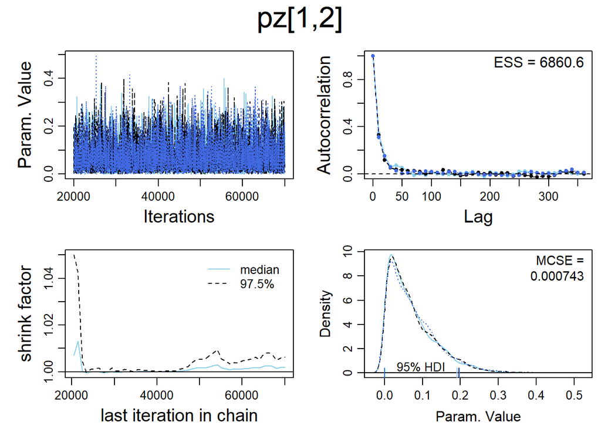

```r
diagMCMC(rjo_1$mcmc, parName="pz[1,2]")
```

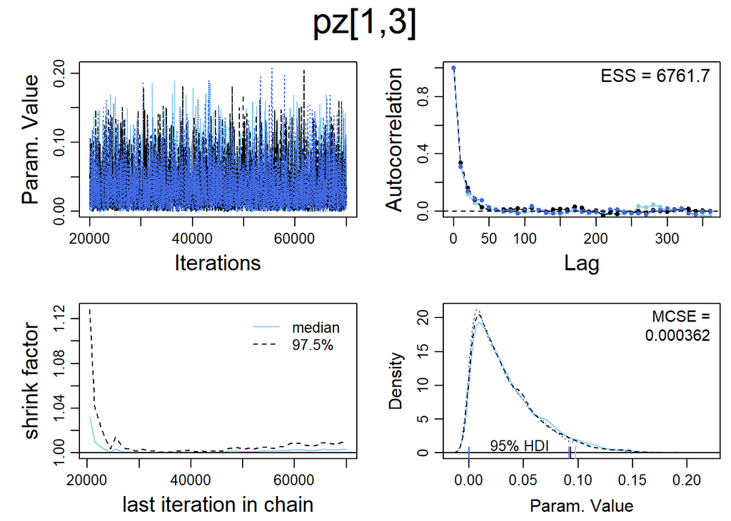

```r
diagMCMC(rjo_1$mcmc, parName="pz[1,3]")
```

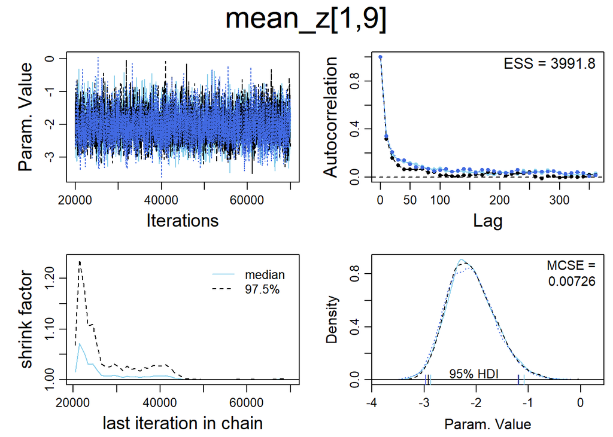

```r
# diagMCMC(rjo_1$mcmc, parName="pz[1,4]")
diagMCMC(rjo_1$mcmc, parName="mean_z[1,9]")
```

# 5 Visualizing Results

Now let’s generate some data structures to store the MCMC output and other relevant data for generating plots and figures.

```r
OMSM_Extract_Posts(
  rjo_1 = rjo_1,
  Data.zoops = Data.zoops,
  Sources,
  Variables,
  Tracers
)
```

## Source tracer values

First we’ll generate some plots of the mean source tracer value posteriors ($\mu_{j,i}$) relative to the original source data.

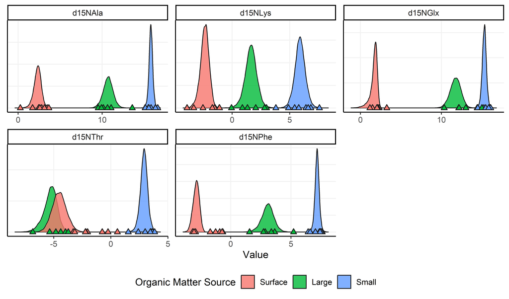

```r
plot_sourcepost_sim(posts.long, Data.sources, Tracers)
```

## MCMC zooplankton parameter posteriors

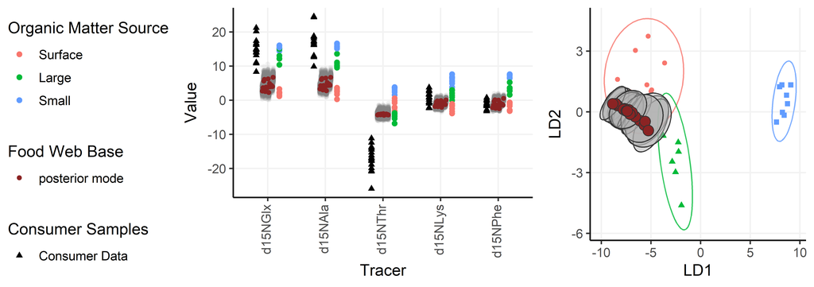

```r
plot_basepost(posts, posts.long, Data.sources, Data.zoops, Tracers, Variables, LDA.full)
   Warning: Using `size` aesthetic for lines was deprecated in ggplot2 3.4.0.
   ℹ Please use `linewidth` instead.
   This warning is displayed once every 8 hours.
   Call `lifecycle::last_lifecycle_warnings()` to see where this warning was
   generated.
```

We also want to look at the mean_z parameter for each zooplankton sample to see if and where the posteriors are deviating from the data.

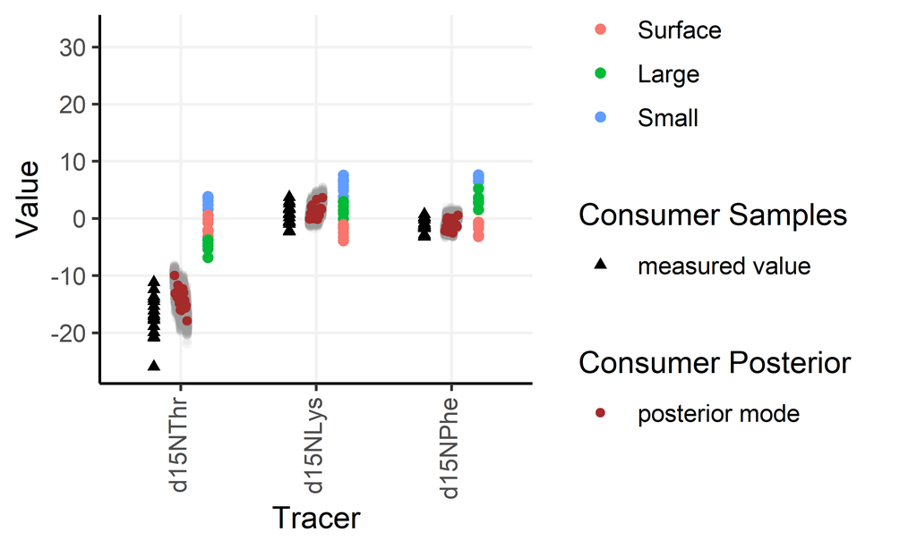

```r
plot_zooppost(
  posts.long,
  Data.zoops,
  Data.sources,
  Tracers
)
   Warning: Removed 44 rows containing missing values or values outside the scale range
   (`geom_point()`).
   Warning: Removed 32 rows containing missing values or values outside the scale range
   (`geom_point()`).
   Warning: Removed 28800 rows containing missing values or values outside the scale range
   (`geom_point()`).
```

We also want to plot up the model posteriors for trophic parameters. The below examples plot posteriors across depth for various sizes of zooplankton. Adjust plots based on your data.

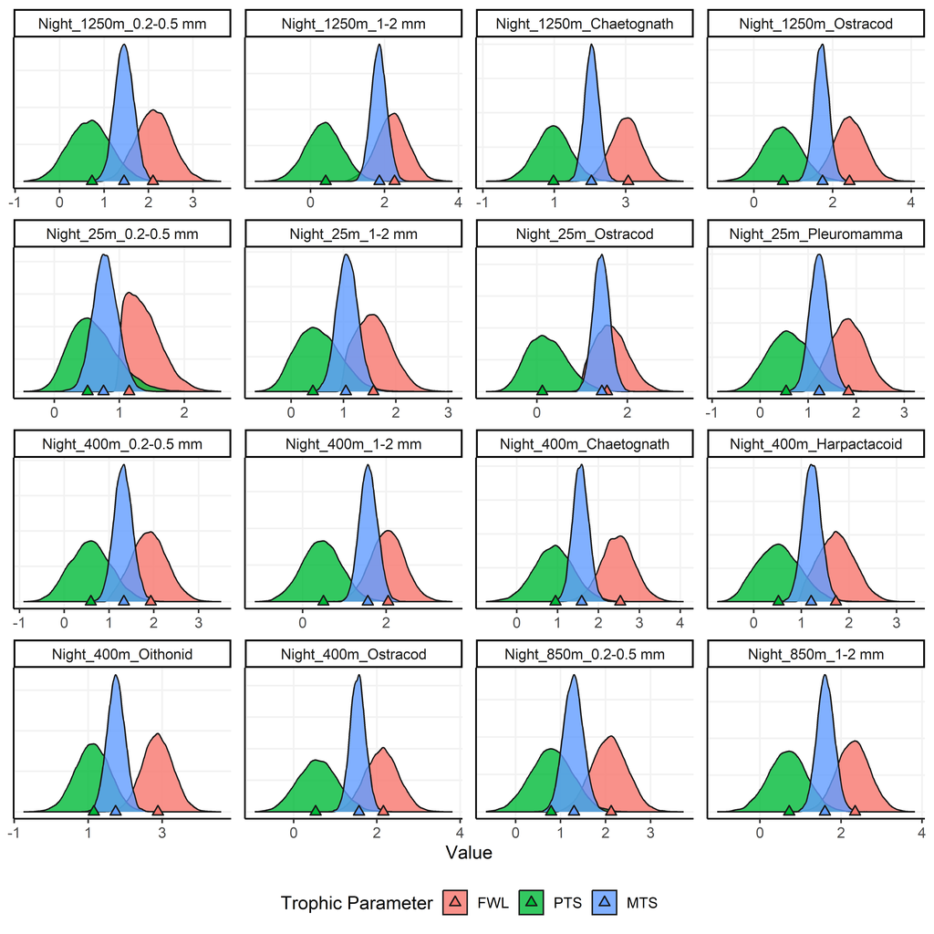

```r
source("Functions/OMSM_Plots.R")      # OMSM posterior plots

plot_trophicpost(
  posts.long
)
```

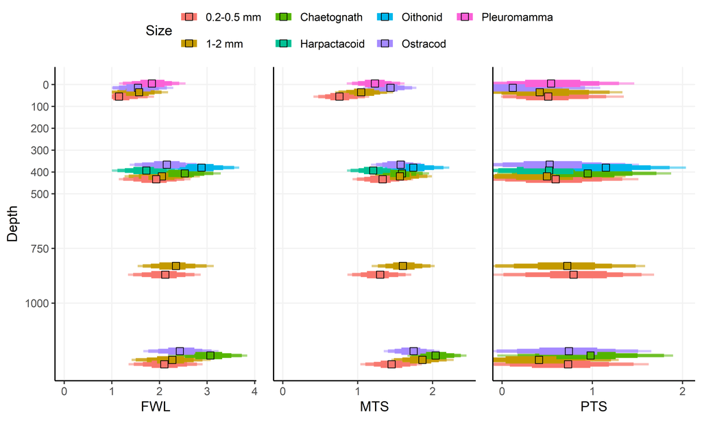

```r
#### Food Web Length ####
plot.FWL <-
  ggplot()+
  geom_line(data = posts$trophic$HDI95,
            aes(x = FWL, y = Depth, group = interaction(Depth, Size), color = Size),
            alpha = 0.5, size = 1,
            position = position_dodgev(height = 80))+
  geom_line(data = posts$trophic$HDI90,
            aes(x = FWL, y = Depth, group = interaction(Depth, Size), color = Size),
            alpha = 0.7, size = 1.5,
            position = position_dodgev(height = 80))+
  geom_line(data = posts$trophic$HDI75,
            aes(x = FWL, y = Depth, group = interaction(Depth, Size), color = Size),
            alpha = 0.9, size = 2,
            position = position_dodgev(height = 80))+
  geom_line(data = posts$trophic$HDI50,
            aes(x = FWL, y = Depth, group = interaction(Depth, Size), color = Size),
            alpha = 1, size = 3,
            position = position_dodgev(height = 80))+
  geom_point(data = posts$trophic$mode,
             aes(x = FWL, y = Depth, group = interaction(Depth, Size), fill = Size),
             size = 3, shape = 22,
             position = position_dodgev(height = 80))+
  scale_y_reverse(breaks = c(0,100,200,300,400,500,750,1000)) +
  scale_x_continuous(breaks = c(0,1,2,3,4,5,6,7,8,9,10))+
  coord_cartesian(xlim = c(0,NA))
#### Metazoan Trophic Steps ####
plot.MTS <-
  ggplot()+
  geom_line(data = posts$trophic$HDI95,
            aes(x = MTS, y = Depth, group = interaction(Depth, Size), color = Size),
            alpha = 0.5, size = 1,
            position = position_dodgev(height = 80))+
  geom_line(data = posts$trophic$HDI90,
            aes(x = MTS, y = Depth, group = interaction(Depth, Size), color = Size),
            alpha = 0.7, size = 1.5,
            position = position_dodgev(height = 80))+
  geom_line(data = posts$trophic$HDI75,
            aes(x = MTS, y = Depth, group = interaction(Depth, Size), color = Size),
            alpha = 0.9, size = 2,
            position = position_dodgev(height = 80))+
  geom_line(data = posts$trophic$HDI50,
            aes(x = MTS, y = Depth, group = interaction(Depth, Size), color = Size),
            alpha = 1, size = 3,
            position = position_dodgev(height = 80))+
  geom_point(data = posts$trophic$mode,
             aes(x = MTS, y = Depth, group = interaction(Depth, Size), fill = Size),
             size = 3, shape = 22,
             position = position_dodgev(height = 80))+
  scale_y_reverse(breaks = c(0,100,200,300,400,500,750,1000)) +
  scale_x_continuous(breaks = c(0,1,2,3,4,5,6,7,8,9,10))+
  coord_cartesian(xlim = c(0,NA))
#### Protozoan Trophic Steps ####
plot.PTS <-
  ggplot()+
  geom_line(data = posts$trophic$HDI95,
            aes(x = PTS, y = Depth, group = interaction(Depth, Size), color = Size),
            alpha = 0.5, size = 1,
            position = position_dodgev(height = 80))+
  geom_line(data = posts$trophic$HDI90,
            aes(x = PTS, y = Depth, group = interaction(Depth, Size), color = Size),
            alpha = 0.7, size = 1.5,
            position = position_dodgev(height = 80))+
  geom_line(data = posts$trophic$HDI75,
            aes(x = PTS, y = Depth, group = interaction(Depth, Size), color = Size),
            alpha = 0.9, size = 2,
            position = position_dodgev(height = 80))+
  geom_line(data = posts$trophic$HDI50,
            aes(x = PTS, y = Depth, group = interaction(Depth, Size), color = Size),
            alpha = 1, size = 3,
            position = position_dodgev(height = 80))+
  geom_point(data = posts$trophic$mode,
             aes(x = PTS, y = Depth, group = interaction(Depth, Size), fill = Size),
             size = 3, shape = 22,
             position = position_dodgev(height = 80))+
  scale_y_reverse(breaks = c(0,100,200,300,400,500,750,1000)) +
  scale_x_continuous(breaks = c(0,1,2,3,4,5,6,7,8,9,10))+
  coord_cartesian(xlim = c(0,NA))

ggarrange(plot.FWL,
          plot.MTS+no.y.axis,
          plot.PTS+no.y.axis,
          nrow=1, widths = c(1.2,1,1), common.legend = TRUE, legend="top")
```

Last we’ll do the same for mixing parameters.

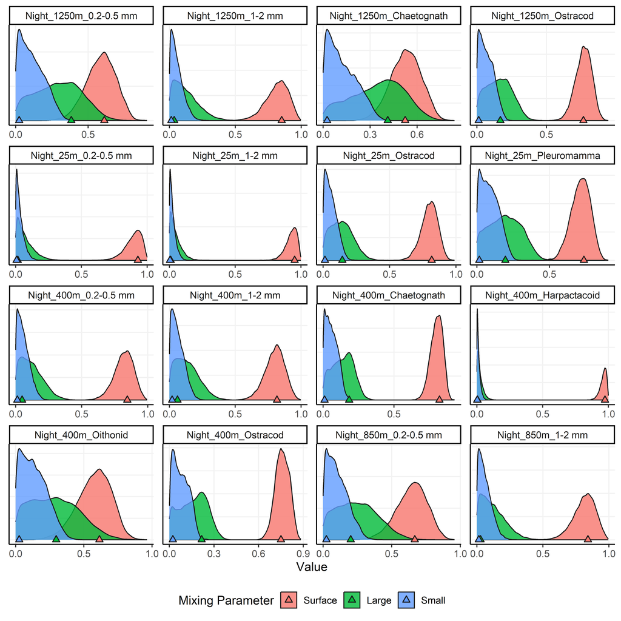

```r
source("Functions/OMSM_Plots.R")      # OMSM posterior plots

plot_fpost(
  posts.long
)
```

```r
#only make ternary plots if there are three sources
if(nsources==3){
  ## Making ternary plots of mixing parameters
  posts$f$samples$model <- "vague prior"

  ggtern(data = posts$f$samples,
         aes(x=Surface,
             y=Large,
             z=Small))+
    stat_confidence_tern(aes(fill=model), color="grey20", alpha=0.4, size=0,
                         breaks=c(0.95,0.90,0.75,0.50), geom = "polygon")+
    scale_fill_manual(values=c("steelblue1","steelblue4"))+
    geom_point(data = posts$f$mode,
               aes(x=Surface, y=Large, z=Small),
               size = 3, shape = 24, fill="steelblue1")+
    theme_bw()+
    theme(legend.position = "none",
          tern.axis.title.T=element_blank(),
          tern.axis.title.L=element_blank(),
          tern.axis.title.R=element_blank())+
    theme_arrowlarge()+
    scale_shape_manual(values = c(24))+
    facet_wrap(~ ID,nrow = 4)
}
   Warning in geom_point(data = posts$f$mode, aes(x = Surface, y = Large, z =
   Small), : Ignoring unknown aesthetics: z
```

[figure not shown]

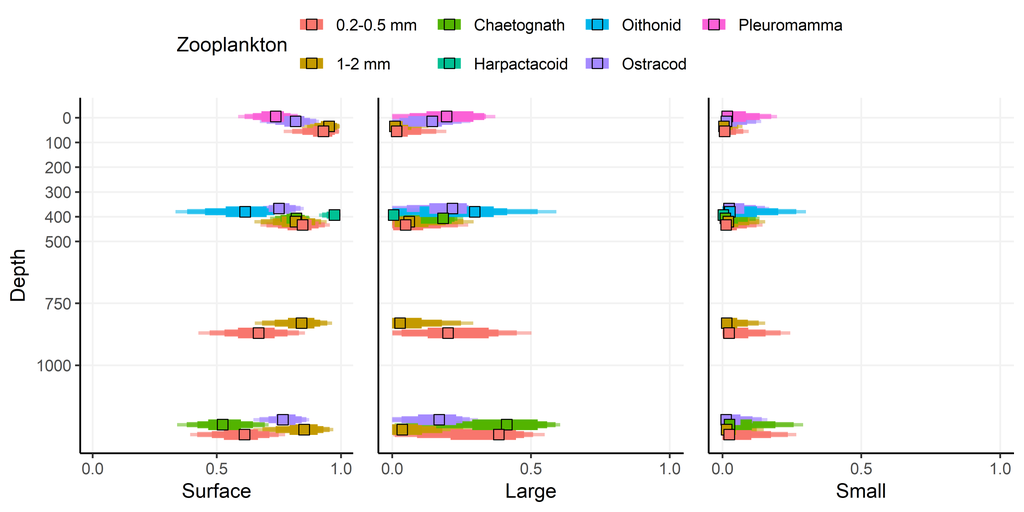

```r
#### f(Surface) ####
plot.Surface <-
  ggplot()+
  geom_line(data = posts$f$HDI95,
            aes(x = Surface, y = Depth, group = interaction(Depth, Size), color = Size),
            alpha = 0.5, size = 1,
            position = position_dodgev(height = 80))+
  geom_line(data = posts$f$HDI90,
            aes(x = Surface, y = Depth, group = interaction(Depth, Size), color = Size),
            alpha = 0.7, size = 1.5,
            position = position_dodgev(height = 80))+
  geom_line(data = posts$f$HDI75,
            aes(x = Surface, y = Depth, group = interaction(Depth, Size), color = Size),
            alpha = 0.9, size = 2,
            position = position_dodgev(height = 80))+
  geom_line(data = posts$f$HDI50,
            aes(x = Surface, y = Depth, group = interaction(Depth, Size), color = Size),
            alpha = 1, size = 3,
            position = position_dodgev(height = 80))+
  geom_point(data = posts$f$mode,
             aes(x = Surface, y = Depth, group = interaction(Depth, Size), fill = Size),
             size = 3, shape = 22,
             position = position_dodgev(height = 80))+
  scale_y_reverse(breaks = c(0,100,200,300,400,500,750,1000)) +
  scale_x_continuous(breaks = c(0,0.50,1))+
  labs(color="Zooplankton",fill="Zooplankton")+
  coord_cartesian(xlim = c(0,1))
#### f(Large) ####
plot.Large <-
  ggplot()+
  geom_line(data = posts$f$HDI95,
            aes(x = Large, y = Depth, group = interaction(Depth, Size), color = Size),
            alpha = 0.5, size = 1,
            position = position_dodgev(height = 80))+
  geom_line(data = posts$f$HDI90,
            aes(x = Large, y = Depth, group = interaction(Depth, Size), color = Size),
            alpha = 0.7, size = 1.5,
            position = position_dodgev(height = 80))+
  geom_line(data = posts$f$HDI75,
            aes(x = Large, y = Depth, group = interaction(Depth, Size), color = Size),
            alpha = 0.9, size = 2,
            position = position_dodgev(height = 80))+
  geom_line(data = posts$f$HDI50,
            aes(x = Large, y = Depth, group = interaction(Depth, Size), color = Size),
            alpha = 1, size = 3,
            position = position_dodgev(height = 80))+
  geom_point(data = posts$f$mode,
             aes(x = Large, y = Depth, group = interaction(Depth, Size), fill = Size),
             size = 3, shape = 22,
             position = position_dodgev(height = 80))+
  scale_y_reverse(breaks = c(0,100,200,300,400,500,750,1000)) +
  scale_x_continuous(breaks = c(0,0.50,1))+
  labs(color="Zooplankton",fill="Zooplankton")+
  coord_cartesian(xlim = c(0,1))
#### f(Small) ####
plot.Small <-
  ggplot()+
  geom_line(data = posts$f$HDI95,
            aes(x = Small, y = Depth, group = interaction(Depth, Size), color = Size),
            alpha = 0.5, size = 1,
            position = position_dodgev(height = 80))+
  geom_line(data = posts$f$HDI90,
            aes(x = Small, y = Depth, group = interaction(Depth, Size), color = Size),
            alpha = 0.7, size = 1.5,
            position = position_dodgev(height = 80))+
  geom_line(data = posts$f$HDI75,
            aes(x = Small, y = Depth, group = interaction(Depth, Size), color = Size),
            alpha = 0.9, size = 2,
            position = position_dodgev(height = 80))+
  geom_line(data = posts$f$HDI50,
            aes(x = Small, y = Depth, group = interaction(Depth, Size), color = Size),
            alpha = 1, size = 3,
            position = position_dodgev(height = 80))+
  geom_point(data = posts$f$mode,
             aes(x = Small, y = Depth, group = interaction(Depth, Size), fill = Size),
             size = 3, shape = 22,
             position = position_dodgev(height = 80))+
  scale_y_reverse(breaks = c(0,100,200,300,400,500,750,1000)) +
  scale_x_continuous(breaks = c(0,0.50,1))+
  labs(color="Zooplankton",fill="Zooplankton")+
  coord_cartesian(xlim = c(0,1))


ggarrange(plot.Surface,
          plot.Large + no.y.axis,
          plot.Small + no.y.axis,
          # plot.Submicron + no.y.axis,
          nrow=1, ncol=3, widths = c(1.1,1,1), common.legend = TRUE, legend="top")
```

# Computing summary statistics

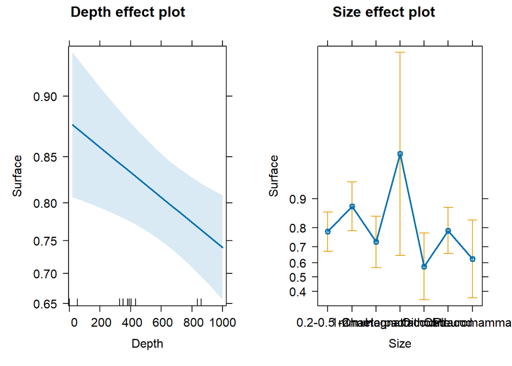

```r
library(effects)
model <- glm(
  Surface ~ Depth + Size,
  data = posts$f$mode,
  family = quasibinomial()
)
anova(model)
   Analysis of Deviance Table

   Model: quasibinomial, link: logit

   Response: Surface

   Terms added sequentially (first to last)


         Df Deviance Resid. Df Resid. Dev      F  Pr(>F)
   NULL                     15    1.51691
   Depth  1  0.36456        14    1.15234 9.4719 0.01517 *
   Size   6  0.84345         8    0.30889 3.6523 0.04756 *
   ---
   Signif. codes:  0 '***' 0.001 '**' 0.01 '*' 0.05 '.' 0.1 ' ' 1
plot(allEffects(model))
```

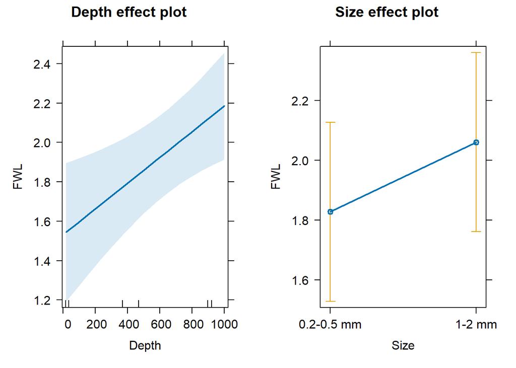

```r
noquote("Posterior mode for f(surface)")
   [1] Posterior mode for f(surface)
noquote("small zoops")
   [1] small zoops
min(subset(posts$f$mode, Size == "0.2-0.5 mm" | Size == "1-2 mm")$Surface)
   [1] 0.6118342
mean(subset(posts$f$mode, Size == "0.2-0.5 mm" | Size == "1-2 mm")$Surface)
   [1] 0.814748
max(subset(posts$f$mode, Size == "0.2-0.5 mm" | Size == "1-2 mm")$Surface)
   [1] 0.9523965
noquote("large zoops")
   [1] large zoops
min(subset(posts$f$mode, Size == "2-5 mm" | Size == ">5 mm")$Surface)
   Warning in min(subset(posts$f$mode, Size == "2-5 mm" | Size == ">5
   mm")$Surface): no non-missing arguments to min; returning Inf
   [1] Inf
mean(subset(posts$f$mode, Size == "2-5 mm" | Size == ">5 mm")$Surface)
   [1] NaN
max(subset(posts$f$mode, Size == "2-5 mm" | Size == ">5 mm")$Surface)
   Warning in max(subset(posts$f$mode, Size == "2-5 mm" | Size == ">5
   mm")$Surface): no non-missing arguments to max; returning -Inf
   [1] -Inf

model <- lm(
  FWL ~ Depth + Size,
  data = subset(posts$trophic$mode,
                Size == "0.2-0.5 mm" | Size == "1-2 mm" |
                  Size == "2-5 mm" | Size == ">5 mm")
)
anova(model)
   Analysis of Variance Table

   Response: FWL
             Df  Sum Sq Mean Sq F value  Pr(>F)
   Depth      1 0.72685 0.72685 13.3765 0.01463 *
   Size       1 0.10887 0.10887  2.0035 0.21609
   Residuals  5 0.27169 0.05434
   ---
   Signif. codes:  0 '***' 0.001 '**' 0.01 '*' 0.05 '.' 0.1 ' ' 1
plot(allEffects(model))
```

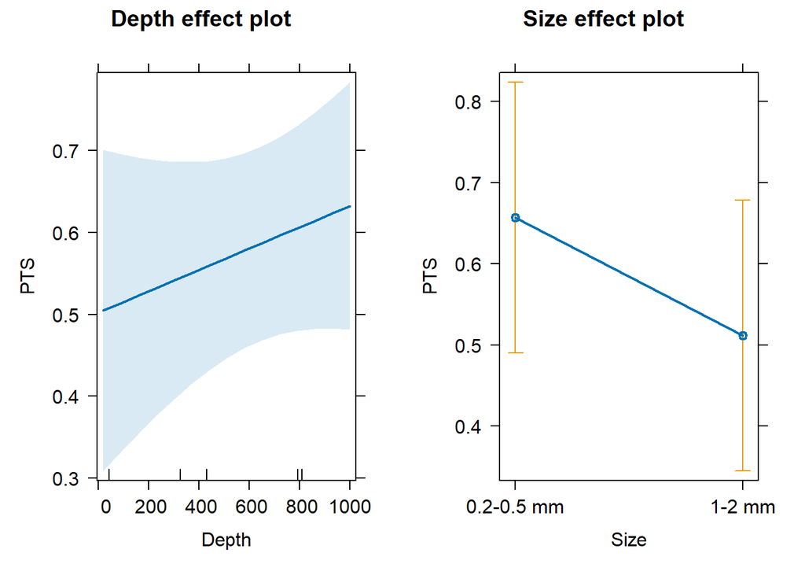

```r
noquote("Posterior mode for FWL")
   [1] Posterior mode for FWL
noquote("EZ")
   [1] EZ
min(subset(posts$trophic$mode, Depth < 100)$FWL)
   [1] 1.15048
mean(subset(posts$trophic$mode, Depth < 100)$FWL)
   [1] 1.528451
max(subset(posts$trophic$mode, Depth < 100)$FWL)
   [1] 1.841725
noquote("MPZ")
   [1] MPZ
min(subset(posts$trophic$mode, Depth > 200)$FWL)
   [1] 1.726723
mean(subset(posts$trophic$mode, Depth > 200)$FWL)
   [1] 2.302357
max(subset(posts$trophic$mode, Depth > 200)$FWL)
   [1] 3.070204

model <- lm(
  PTS ~ Depth + Size,
  data = subset(posts$trophic$mode,
                Size == "0.2-0.5 mm" | Size == "1-2 mm" |
                  Size == "2-5 mm" | Size == ">5 mm")
)
anova(model)
   Analysis of Variance Table

   Response: PTS
             Df   Sum Sq  Mean Sq F value Pr(>F)
   Depth      1 0.028894 0.028894  1.7139 0.2474
   Size       1 0.042221 0.042221  2.5045 0.1744
   Residuals  5 0.084291 0.016858
plot(allEffects(model))
```

```r
noquote("Posterior mode for PTS")
   [1] Posterior mode for PTS
noquote("all zoops")
   [1] all zoops
min(subset(posts$trophic$mode)$PTS)
   [1] 0.1186268
mean(subset(posts$trophic$mode)$PTS)
   [1] 0.6379152
max(subset(posts$trophic$mode)$PTS)
   [1] 1.15105
```

# Exporting results

The last thing we want to do here is export out mixing model results to a .RData file. Load this file into other R scripts to do additional analyses.

```r
save(posts,
     posts.long,
     Data.all,
     file = paste0("Data/",export.file.name))
```